# SS-tutorial

Nicholaus Brosowsky

1/13/2019

# Visualizing variance in a single-factor / 2-level design

```r
oneway <- read.csv(file = "oneway.csv")

#let's reorder the data frame by group index
oneway<-oneway[order(oneway$garden),]
oneway$observations<-1:20
```

### Plot the data points

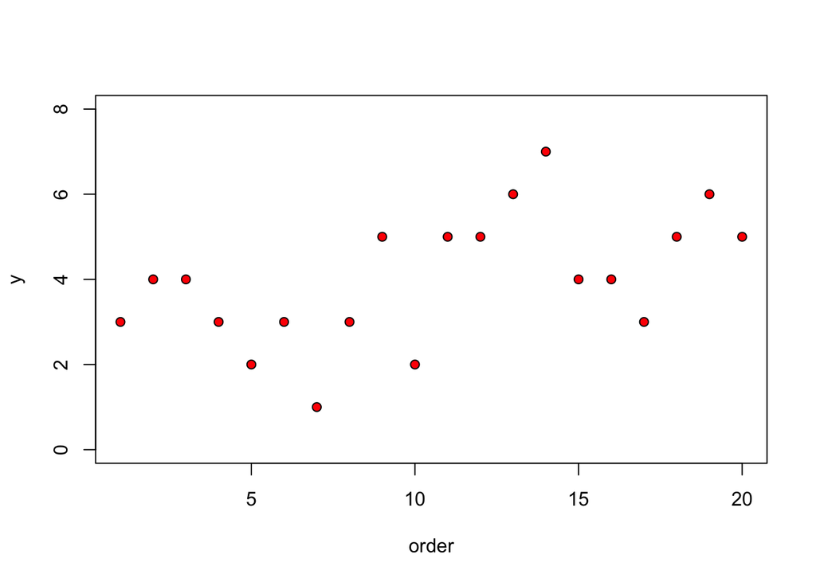

```r
plot(oneway$observations,
     oneway$ozone,
     ylim=c(min(oneway$ozone) - 1,max(oneway$ozone) + 1),
     ylab="y",xlab="order",
     pch=21, bg="red")
```

### Plot the residuals around the grand mean

This plot visualizes the overall variation in our data and corresponds with the *total sum of squares*

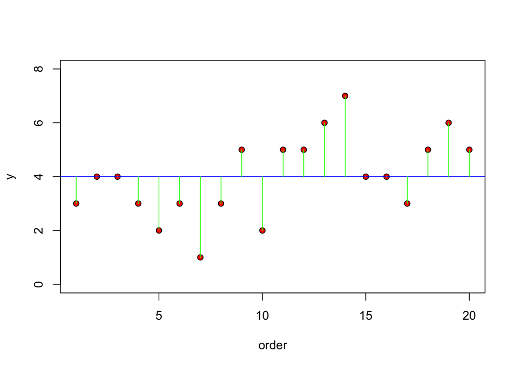

```r
plot(oneway$observations,
     oneway$ozone,
     ylim=c(min(oneway$ozone) - 1,max(oneway$ozone) + 1),ylab="y",xlab="order",pch=21,bg="red")

#add horizontal line
abline(h=mean(oneway$ozone),col="blue")

#add vertical lines for residuals
for(i in 1:20) lines(c(i,i),c(mean(oneway$ozone),oneway$ozone[i]),col="green")
```

### Plot the residuals around each group mean

This plot visualizes the variation around each group mean. It corresponds with the *error sum of squares* or *within-groups sum of squares*

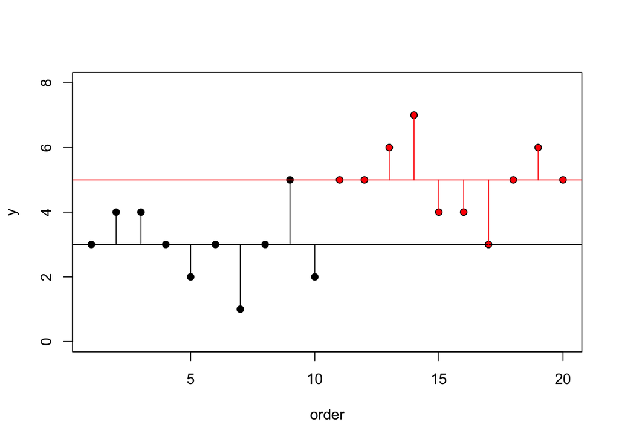

```r
plot(oneway$observations,
     oneway$ozone,ylim=c(min(oneway$ozone) - 1,max(oneway$ozone) + 1),
     ylab="y",xlab="order",
     pch=21,bg=as.numeric(oneway$garden)
     )

# add horizontal lines for means
abline(h=mean(oneway[oneway$garden=="A",]$ozone))
abline(h=mean(oneway[oneway$garden=="B",]$ozone),col="red")

# add residual vertical lines
for (i in 1:nrow(oneway)){
if (oneway$garden[i] == "A")
lines(c(i,i),c(mean(oneway[oneway$garden=="A",]$ozone),oneway$ozone
[i]))
else
lines(c(i,i),c(mean(oneway[oneway$garden=="B",]$ozone),oneway$ozone
[i]), col="red")
}
```

### Plot group mean deviations around the grand mean

This plot visualizes the group deviations from the grand mean. It corresponds with the *between-groups sum of squares* or the variance accounted for by our manipulation

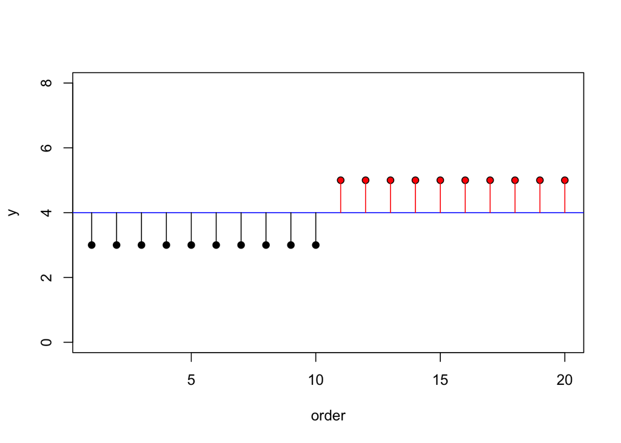

```r
oneway$groupMeans<-c(rep(mean(oneway[oneway$garden=="A",]$ozone),10),
                     rep(mean(oneway[oneway$garden=="B",]$ozone),10))


plot(oneway$observations,
     oneway$groupMeans,ylim=c(min(oneway$ozone) - 1,max(oneway$ozone) + 1),
     ylab="y",xlab="order",
     pch=21,bg=as.numeric(oneway$garden)
     )

# add horizontal line
abline(h=mean(oneway$ozone),col="blue")

# add residual vertical lines
for (i in 1:nrow(oneway)){
if (oneway$garden[i] == "A")
lines(c(i,i),c(mean(oneway$ozone),oneway$groupMeans
[i]))
else
lines(c(i,i),c(mean(oneway$ozone),oneway$groupMeans
[i]), col="red")
}
```

### Programming Challenge #1

If the means in the two gardens are not significantly different, what should be the difference in the lengths of the red and black residual lines in this figure and the green lines in the first figure we drew?

**Answer:** if the means were the same, then the red and black horizontal lines in this figure would be in the same place, and hence the lengths of the residual lines would be the same as in the previous figure.

Let’s simulate that.

1. Simulate data from an experiment with a single independent variable and two levels where there is no difference between the means.

e.g., Group A: mean = 4, sd = 1 Group B: mean = 4, sd = 1

2. Copy the data into the oneway dataframe
3. Copy/paste the code above to plot residuals for your simulated data.

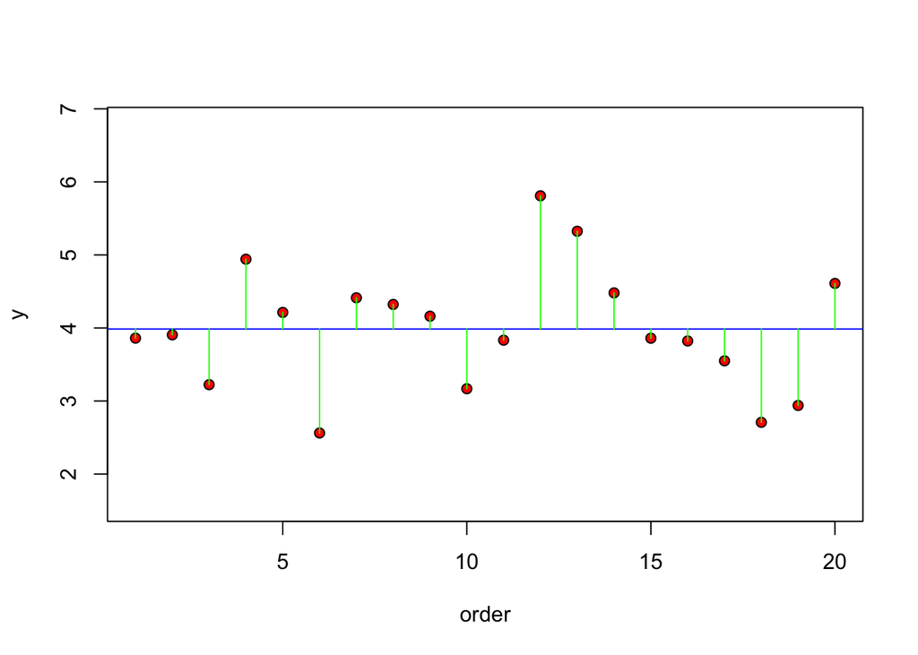

```r
# simulate new ozone data
oneway$ozone<-rnorm(20, mean = 4, sd = 1)

# plot residuals around the grand mean
plot(oneway$observations,
     oneway$ozone,
     ylim=c(min(oneway$ozone) - 1,max(oneway$ozone) + 1),ylab="y",xlab="order",pch=21,bg="red")

#add horizontal line
abline(h=mean(oneway$ozone),col="blue")

#add vertical lines for residuals
for(i in 1:20) lines(c(i,i),c(mean(oneway$ozone),oneway$ozone[i]),col="green")
```

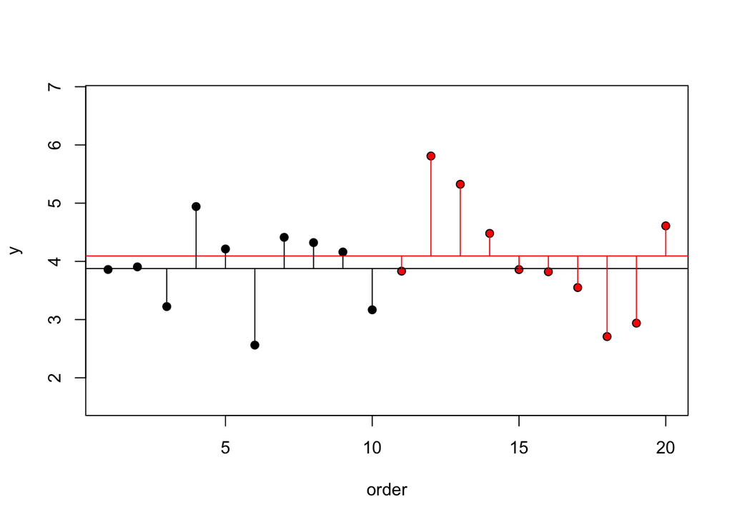

```r
# plot residuals around the group means
plot(oneway$observations,
     oneway$ozone,ylim=c(min(oneway$ozone) - 1,max(oneway$ozone) + 1),
     ylab="y",xlab="order",
     pch=21,bg=as.numeric(oneway$garden)
     )

# add horizontal lines for means
abline(h=mean(oneway[oneway$garden=="A",]$ozone))
abline(h=mean(oneway[oneway$garden=="B",]$ozone),col="red")

# add residual vertical lines
for (i in 1:nrow(oneway)){
if (oneway$garden[i] == "A")
lines(c(i,i),c(mean(oneway[oneway$garden=="A",]$ozone),oneway$ozone
[i]))
else
lines(c(i,i),c(mean(oneway[oneway$garden=="B",]$ozone),oneway$ozone
[i]), col="red")
}
```

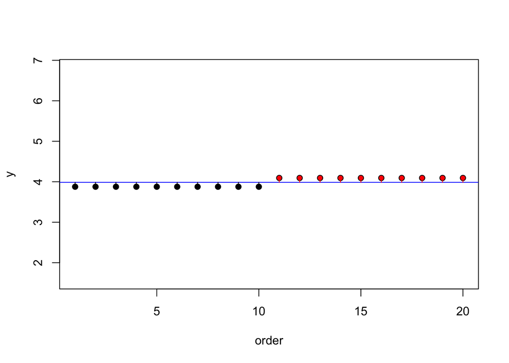

```r
oneway$groupMeans<-c(rep(mean(oneway[oneway$garden=="A",]$ozone),10),
                     rep(mean(oneway[oneway$garden=="B",]$ozone),10))


plot(oneway$observations,
     oneway$groupMeans,ylim=c(min(oneway$ozone) - 1,max(oneway$ozone) + 1),
     ylab="y",xlab="order",
     pch=21,bg=as.numeric(oneway$garden)
     )

# add horizontal line
abline(h=mean(oneway$ozone),col="blue")

# add residual vertical lines
for (i in 1:nrow(oneway)){
if (oneway$garden[i] == "A")
lines(c(i,i),c(mean(oneway$ozone),oneway$groupMeans
[i]))
else
lines(c(i,i),c(mean(oneway$ozone),oneway$groupMeans
[i]), col="red")
}
```

### Programming Challenge #2

Now, suppose that mean ozone concentration is different in the two gardens. Would the residual lines be bigger or smaller when we compute them from the individual treatment means (the red and black lines, as above), or from the overall mean (the green lines in the previous figure)?

Answer: They would be smaller when computed from the individual treatment means if the individual treatment means were different.

Let’s simulate that.

1. Simulate data from an experiment with a single independent variable and two levels where there is a difference between the means.

2. Add the data to the oneway data frame
3. Copy/paste the code above to plot residuals for your simulated data.

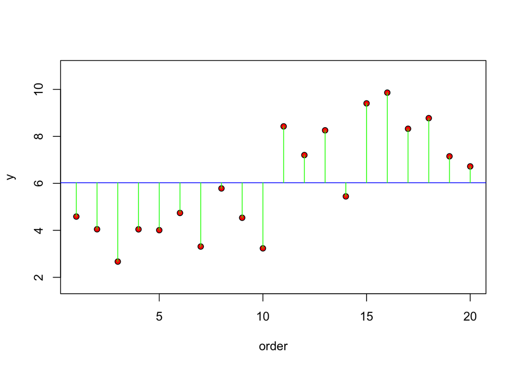

```r
# simulate new ozone data
oneway$ozone<-c(rnorm(10, mean = 4, sd = 1),
                rnorm(10, mean = 8, sd = 1)
)


# plot residuals around the grand mean
plot(oneway$observations,
     oneway$ozone,
     ylim=c(min(oneway$ozone) - 1,max(oneway$ozone) + 1),ylab="y",xlab="order",pch=21,bg="red")

#add horizontal line
abline(h=mean(oneway$ozone),col="blue")

#add vertical lines for residuals
for(i in 1:20) lines(c(i,i),c(mean(oneway$ozone),oneway$ozone[i]),col="green")
```

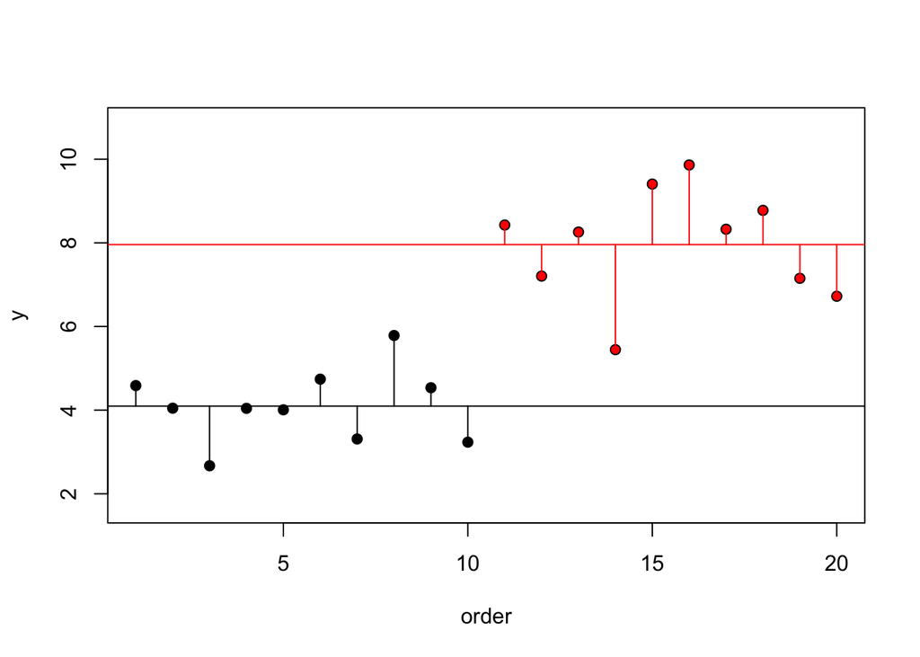

```r
# plot residuals around the group means
plot(oneway$observations,
     oneway$ozone,ylim=c(min(oneway$ozone) - 1,max(oneway$ozone) + 1),
     ylab="y",xlab="order",
     pch=21,bg=as.numeric(oneway$garden)
     )

# add horizontal lines for means
abline(h=mean(oneway[oneway$garden=="A",]$ozone))
abline(h=mean(oneway[oneway$garden=="B",]$ozone),col="red")

# add residual vertical lines
for (i in 1:nrow(oneway)){
if (oneway$garden[i] == "A")
lines(c(i,i),c(mean(oneway[oneway$garden=="A",]$ozone),oneway$ozone
[i]))
else
lines(c(i,i),c(mean(oneway[oneway$garden=="B",]$ozone),oneway$ozone
[i]), col="red")
}
```

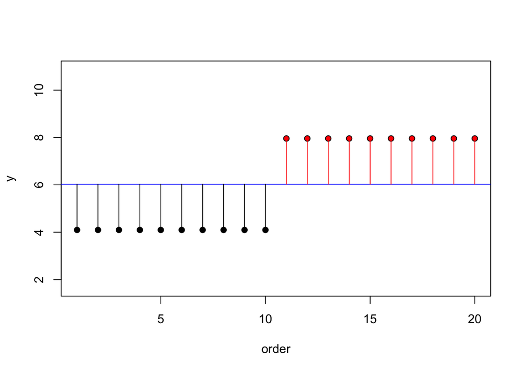

```r
oneway$groupMeans<-c(rep(mean(oneway[oneway$garden=="A",]$ozone),10),
                     rep(mean(oneway[oneway$garden=="B",]$ozone),10))


plot(oneway$observations,
     oneway$groupMeans,ylim=c(min(oneway$ozone) - 1,max(oneway$ozone) + 1),
     ylab="y",xlab="order",
     pch=21,bg=as.numeric(oneway$garden)
     )

# add horizontal line
abline(h=mean(oneway$ozone),col="blue")

# add residual vertical lines
for (i in 1:nrow(oneway)){
if (oneway$garden[i] == "A")
lines(c(i,i),c(mean(oneway$ozone),oneway$groupMeans
[i]))
else
lines(c(i,i),c(mean(oneway$ozone),oneway$groupMeans
[i]), col="red")
}
```